# Disease Ontology Semantic and Enrichment analysis

Guangchuang Yu (guangchuangyu@gmail.com) School of Public Health, The University of Hong Kong

2015-08-26

# 1 Abstract

Disease Ontology (DO) aims to provide an open source ontology for the integration of biomedical data that is associated with human disease. We developed *[DOSE](http://bioconductor.org/packages/release/bioc/html/DOSE.html)* package to promote the investigation of diseases. *[DOSE](http://bioconductor.org/packages/release/bioc/html/DOSE.html)* provides five methods including Resnik, Lin, Jiang, Rel and Wang for measuring semantic similarities among DO terms and gene products; Hypergeometric model and gene set enrichment analysis were also implemented for extracting disease association insight from genome wide expression profiles.

# 2 Citation

If you use *[DOSE](http://bioconductor.org/packages/release/bioc/html/DOSE.html)* in published research, please cite:

```
G Yu, LG Wang, GR Yan, QY He.
DOSE: an R/Bioconductor package for Disease Ontology Semantic and Enrichment analysis
Bioinformatics 2015, 31(4):608-609.
```

URL: http://dx.doi.org/10.1093/bioinformatics/btu684

# 3 Introduction

Public health is an important driving force behind biological and medical research. A major challenge of the post-genomic era is bridging the gap between fundamental biological research and its clinical applications. Recent research has increasingly demonstrated that many seemingly dissimilar diseases have common molecular mechanisms. Understanding similarities among disease aids in early diagnosis and new drug development.

Formal knowledge representation of gene-disease association is demanded for this purpose. Ontologies, such as Gene Ontology, have been successfully applied to represent biological knowledge, and many related techniques have been adopted to extract information. Disease Ontology (DO)<sup>1</sup> was developed to create a consistent description of gene products with disease perspectives, and is essential for supporting functional genomics in disease context. Accurate disease descriptions can discover new relationships between genes and disease, and new functions for previous uncharacteried genes and alleles.

Unlike other clinical vocabularies that defined disease related concepts disparately, DO is organized as a directed acyclic graph, laying the foundation for quantitative computation of disease knowledge. The application of disease ontology is in its infancy, lacking programs for mining DO knowledge automatically.

Four information content (IC)-based methods and one graph structure-based method were implemented for measuring semantic similarity. Hypergeometric test and Gene Set Enrichment Analysis were implemented for extracting biological insight.

To start with *[DOSE](http://bioconductor.org/packages/release/bioc/html/DOSE.html)* package, type following code below:

```r
library(DOSE)
help(DOSE)
```

# 4 DO term semantic similarity measurement

Four methods determine the semantic similarity of two terms based on the Information Content of their common ancestor term were proposed by Resnik<sup>3</sup>, Jiang<sup>4</sup>, Lin<sup>5</sup> and Schlicker<sup>6</sup>. Wang<sup>7</sup> presented a method to measure the similarity based on the graph structure. Each of these methods has its own advantage and weakness. *[DOSE](http://bioconductor.org/packages/release/bioc/html/DOSE.html)* implemented all these methods to compute semantic similarity among DO terms and gene products. We have developed another package *[GOSemSim](http://bioconductor.org/packages/release/bioc/html/GOSemSim.html)*<sup>8</sup> to explore the functional similarity at GO perspective, including molecular function (MF), biological process (BP) and cellular component (CC).

For algorithm details, please refer to the vignette of *[GOSemSim](http://bioconductor.org/packages/release/bioc/html/GOSemSim.html)*.

## 4.1 doSim function

In *[DOSE](http://bioconductor.org/packages/release/bioc/html/DOSE.html)*, we implemented *doSim* for calculating semantic similarity between two DO terms and two set of DO terms.

```r
data(DO2EG)
set.seed(123)
a <- sample(names(DO2EG), 10)
a
```

```
##  [1] "DOID:1407"  "DOID:5844"  "DOID:2034"  "DOID:8432"  "DOID:9146"
##  [6] "DOID:10584" "DOID:3209"  "DOID:848"   "DOID:3341"  "DOID:2512"
```

```r
b <- sample(names(DO2EG), 5)
b
```

```
## [1] "DOID:9409"  "DOID:2481"  "DOID:4465"  "DOID:3498"  "DOID:11252"
```

```r
doSim(a[1], b[1], measure="Wang")
```

```
## [1] 0.1132852
```

```r
doSim(a[1], b[1], measure="Resnik")
```

```
## [1] 0.0809122
```

```r
doSim(a[1], b[1], measure="Lin")
```

```
## [1] 0.09407429
```

```r
s <- doSim(a, b, measure="Wang")
s
```

```
##             DOID:9409  DOID:2481  DOID:4465  DOID:3498 DOID:11252
## DOID:1407  0.11328518 0.08595600 0.01522238 0.01522238 0.08190022
## DOID:5844  0.14897652 0.07834240 0.02801328 0.02801328 0.11564838
## DOID:2034  0.17347273 0.47553108 0.03676194 0.03676194 0.13877811
## DOID:8432  0.17347273 0.09998997 0.03676194 0.03676194 0.42199873
## DOID:9146  0.07142995 0.04117234 0.03676194 0.03676194 0.05714393
## DOID:10584 0.12108370 0.09869482 0.01802164 0.01802164 0.08927900
## DOID:3209  0.14897652 0.07834240 0.02801328 0.02801328 0.11564838
## DOID:848   0.14897652 0.07834240 0.02801328 0.02801328 0.11564838
## DOID:3341  0.13240905 0.06367153 0.02208240 0.02208240 0.09998997
## DOID:2512  0.07142995 0.04117234 0.03676194 0.03676194 0.05714393
```

The *doSim* function requires three parameter *DOID1*, *DOID2* and *measure*. *DOID1* and *DOID2* should be a vector of DO terms, while *measure* should be one of Resnik, Jiang, Lin, Rel, and Wang.

We also implement a plot function *simplot* to visualize the similarity result.

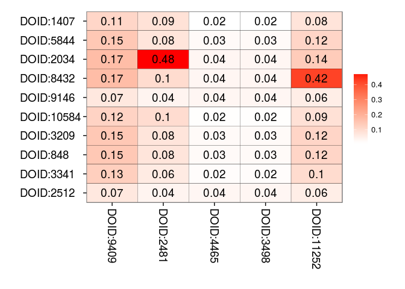

```r
simplot(s,
        color.low="white", color.high="red",
        labs=TRUE, digits=2, labs.size=5,
        font.size=14, xlab="", ylab="")
```

Parameter *color.low* and *colow.high* are used to setting the color gradient; *labs* is a logical parameter indicating whether to show the similarity values or not, *digits* to indicate the number of decimal places to be used and *labs.size* control the font size of similarity values; *font.size* setting the font size of axis and label of the coordinate system.

# 5 Gene semantic similarity measurement

On the basis of semantic similarity between DO terms, *[DOSE](http://bioconductor.org/packages/release/bioc/html/DOSE.html)* can also compute semantic similarity among gene products. *[DOSE](http://bioconductor.org/packages/release/bioc/html/DOSE.html)* provides four methods which called *max*, *avg*, *rcmax* and *BMA* to combine semantic similarity scores of multiple DO terms. The similarities among genes and gene clusters which annotated by multiple DO terms were also calculated by these combine methods. For calculation details, please refer to the vignette of *[GOSemSim](http://bioconductor.org/packages/release/bioc/html/GOSemSim.html)*.

## 5.1 geneSim function

In *[DOSE](http://bioconductor.org/packages/release/bioc/html/DOSE.html)*, we implemented *geneSim* to measure semantic similarities among genes.

```r
data(EG2DO)
g1 <- sample(names(EG2DO), 5)
g1
```

```
## [1] "84842" "2521"  "10592" "3069"  "91746"
```

```r
g2 <- sample(names(EG2DO), 4)
g2
```

```
## [1] "84289" "6045"  "56999" "9869"
```

```r
geneSim(g1[1], g2[1], measure="Wang", combine="BMA")
```

```
## [1] 0.057
```

```r
gs <- geneSim(g1, g2, measure="Wang", combine="BMA")
gs
```

```
##       84289  6045 56999  9869
## 84842 0.057 0.135 0.355 0.098
## 2521  0.573 0.253 0.511 0.482
## 10592 0.057 0.187 0.296 0.128
## 3069  0.573 0.517 1.000 1.000
## 91746 0.573 0.308 0.527 0.501
```

The *geneSim* requires four parameter *geneID1*, *geneID2*, *measure* and *combine*. *geneID1* and *geneID2* should be a vector of entrez gene IDs; *measure* should be one of Resnik, Jiang, Lin, Rel, and Wang, while *combine* should be one of max, avg, rcmax and BMA as described previously.

The *simplot* works well with both the output of *doSim* and *geneSim*.

## 5.2 clusterSim and mclusterSim

We also implemented *clusterSim* for calculating semantic similarity between two gene clusters and *mclusterSim* for calculating semantic similarities among multiple gene clusters.

```r
clusterSim(g1, g2, measure="Wang", combine="BMA")
```

```
## [1] 0.501
```

```r
clusters <- list(a=g1, b=g2, c=sample(names(EG2DO), 6))
mclusterSim(clusters, measure="Wang", combine="BMA")
```

```
##       a     b     c
## a 1.000 0.501 0.403
## b 0.501 1.000 0.623
## c 0.403 0.623 1.000
```

# 6 DO term enrichment analysis

## 6.1 Hypergeometric model

Over-representation test<sup>9</sup> is a widely used approach to identify biological themes. Here we implement hypergeometric model to assess whether the number of selected genes associated with disease is larger than expected.

To determine whether any terms annotate a specified list of genes at frequency greater than that would be expected by chance, *[DOSE](http://bioconductor.org/packages/release/bioc/html/DOSE.html)* calculates a p-value using the hypergeometric distribution:

$p = 1 - \displaystyle\sum_{i = 0}^{k-1}\frac{{M \choose i}{{N-M} \choose {n-i}}} {{N \choose n}}$

In this equation, *N* is the total number of genes in the background distribution, *M* is the number of genes within that distribution that are annotated (either directly or indirectly) to the node of interest, *n* is the size of the list of genes of interest and *k* is the number of genes within that list which are annotated to the node. The background distribution by default is all the genes that have annotation. User can set the background via *universe* parameter.

P-values were adjusted for multiple comparison, and q-values were also calculated for FDR control.

## 6.2 enrichDO function

*[DOSE](http://bioconductor.org/packages/release/bioc/html/DOSE.html)* provides an example dataset *geneList* which was derived from `R` package *[breastCancerMAINZ](http://bioconductor.org/packages/release/bioc/html/breastCancerMAINZ.html)* that contained 200 samples, including 29 samples in grade I, 136 samples in grade II and 35 samples in grade III. We computed the ratios of geometric means of grade III samples versus geometric means of grade I samples. Logarithm of these ratios (base 2) were stored in *geneList* dataset.

```r
data(geneList)
gene <- names(geneList)[abs(geneList) > 1.5]
head(gene)
```

```
## [1] "4312"  "8318"  "10874" "55143" "55388" "991"
```

```r
x <- enrichDO(gene          = gene,
              ont           = "DO",
              pvalueCutoff  = 0.05,
              pAdjustMethod = "BH",
              universe      = names(geneList),
              minGSSize     = 5,
              qvalueCutoff  = 0.05,
              readable      = FALSE)
head(summary(x))
```

```
##                        ID                       Description GeneRatio
## DOID:162         DOID:162                            cancer   266/331
## DOID:14566     DOID:14566 disease of cellular proliferation   267/331
## DOID:0050686 DOID:0050686               organ system cancer   187/331
## DOID:2994       DOID:2994                  germ cell cancer    47/331
## DOID:193         DOID:193         reproductive organ cancer    61/331
## DOID:10283     DOID:10283                   prostate cancer    40/331
##                BgRatio       pvalue     p.adjust       qvalue
## DOID:162     4259/6274 1.409970e-07 0.0001230903 9.483901e-05
## DOID:14566   4307/6274 3.266965e-07 0.0001426030 1.098732e-04
## DOID:0050686 2756/6274 1.610655e-06 0.0004687006 3.611258e-04
## DOID:2994     483/6274 2.269485e-05 0.0045378581 3.496342e-03
## DOID:193      691/6274 2.599002e-05 0.0045378581 3.496342e-03
## DOID:10283    394/6274 3.777164e-05 0.0054957741 4.234400e-03
##                                                                                                                                                                                                                                                                                                          …
## DOID:162          4312/8318/10874/55143/991/6280/2305/1062/4605/9833/9133/6279…
## DOID:14566   4312/8318/10874/55143/991/6280/2305/1062/4605/9833/9133/6279…
## DOID:0050686                                                                                                                                                                                                                                                                                             …
## DOID:2994                                                                                                                                                                                                                                                                                                …
## DOID:193                                                                                                                                                                                                                                                                                                 …
## DOID:10283                                                                                                                                                                                                                                                                                               …
##              Count
## DOID:162       266
## DOID:14566     267
## DOID:0050686   187
## DOID:2994       47
## DOID:193        61
## DOID:10283      40
```

The *enrichDO* function requires an entrezgene ID vector as input, mostly is the differential gene list of gene expression profile studies. If user needs to convert other gene ID type to entrezgene ID, we recommend using *bitr* function provided by *[clusterProfiler](http://bioconductor.org/packages/release/bioc/html/clusterProfiler.html)*.

The *ont* parameter can be “DO” or “DOLite”, DOLite<sup>10</sup> was constructed to aggregate the redundant DO terms. The DOLite data is not updated, we recommend user use *ont=“DO”*. *pvalueCutoff* setting the cutoff value of p value and p value adjust; *pAdjustMethod* setting the p value correction methods, include the Bonferroni correction (“bonferroni”), Holm (“holm”), Hochberg (“hochberg”), Hommel (“hommel”), Benjamini & Hochberg (“BH”) and Benjamini & Yekutieli (“BY”) while *qvalueCutoff* is used to control q-values.

The *universe* setting the background gene universe for testing. If user do not explicitly setting this parameter, *enrichDO* will set the universe to all human genes that have DO annotation.

The *readable* is a logical parameter, indicates whether the entrezgene IDs will mapping to gene symbols or not.

We also implement *setReadable* function that helps the user to convert entrezgene IDs to gene symbols.

```r
x <- setReadable(x)
head(summary(x))
```

```
##                        ID                       Description GeneRatio
## DOID:162         DOID:162                            cancer   266/331
## DOID:14566     DOID:14566 disease of cellular proliferation   267/331
## DOID:0050686 DOID:0050686               organ system cancer   187/331
## DOID:2994       DOID:2994                  germ cell cancer    47/331
## DOID:193         DOID:193         reproductive organ cancer    61/331
## DOID:10283     DOID:10283                   prostate cancer    40/331
##                BgRatio       pvalue     p.adjust       qvalue
## DOID:162     4259/6274 1.409970e-07 0.0001230903 9.483901e-05
## DOID:14566   4307/6274 3.266965e-07 0.0001426030 1.098732e-04
## DOID:0050686 2756/6274 1.610655e-06 0.0004687006 3.611258e-04
## DOID:2994     483/6274 2.269485e-05 0.0045378581 3.496342e-03
## DOID:193      691/6274 2.599002e-05 0.0045378581 3.496342e-03
## DOID:10283    394/6274 3.777164e-05 0.0054957741 4.234400e-03
##                                                                                                                                                                                                                                                                                                          …
## DOID:162             MMP1/CDC45/NMU/CDCA8/CDC20/S100A9/FOXM1/CENPE/MYBL2/MELK/CCN…-2/EPHX3/GGH/TAP1/CBS/CRISP3/HMGA1/BCL11A/ECT2/GALNT14/TFPI2/…-DQA1/CCDC170/ADH1B/NOVA1/PDZK1/EMX2/ACKR1/SCGB2A2/PSD3/FABP4/BMP4/LRP2/MAPT/WISP2/ERBB4/FOXA1/CRY2/CXCL14/GRP/CYP4F8/TPSB2/CX3CR1/CYP4B1/SCGB1D2/PIP/STC…
## DOID:14566   MMP1/CDC45/NMU/CDCA8/CDC20/S100A9/FOXM1/CENPE/MYBL2/MELK/CCN…-2/EPHX3/GGH/TAP1/CBS/CRISP3/HMGA1/BCL11A/ECT2/GALNT14/TFPI2/…-DQA1/CCDC170/ADH1B/NOVA1/PDZK1/EMX2/ACKR1/SCGB2A2/PSD3/FABP4/BMP4/LRP2/MAPT/WISP2/ERBB4/FOXA1/CRY2/CXCL14/GRP/CYP4F8/TPSB2/CX3CR1/CYP4B1/SCGB1D2/PIP/STC2/GATA3/…
## DOID:0050686                                                                                                                                                                                                                                                                                             …
## DOID:2994                                                                                                                                                                                                                                                                                                …
## DOID:193                                                                                                                                                                                                                                                                                                 …
## DOID:10283                                                                                                                                                                                                                                                                                               …
##              Count
## DOID:162       266
## DOID:14566     267
## DOID:0050686   187
## DOID:2994       47
## DOID:193        61
## DOID:10283      40
```

## 6.3 Visualze enrichment result

We also implement a bar plot and category-gene-network for visualization. It is very common to visualize the enrichment result in bar or pie chart. We believe the pie chart is misleading and only provide bar chart.

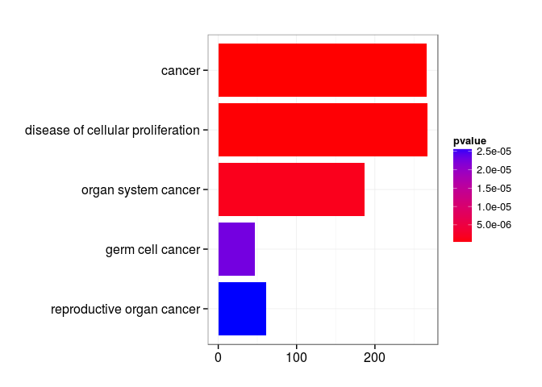

```r
barplot(x)
```

[*dotplot*](http://ygc.name/2015/06/23/dotplot-for-enrichment-result/) is a good alternative to *barplot*.

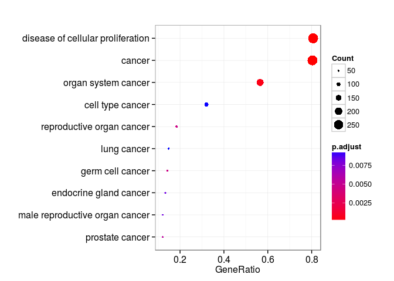

```r
dotplot(x)
```

In order to consider the potentially biological complexities in which a gene may belong to multiple annotation categories, we developed *cnetplot* function to extract the complex association between genes and diseases.

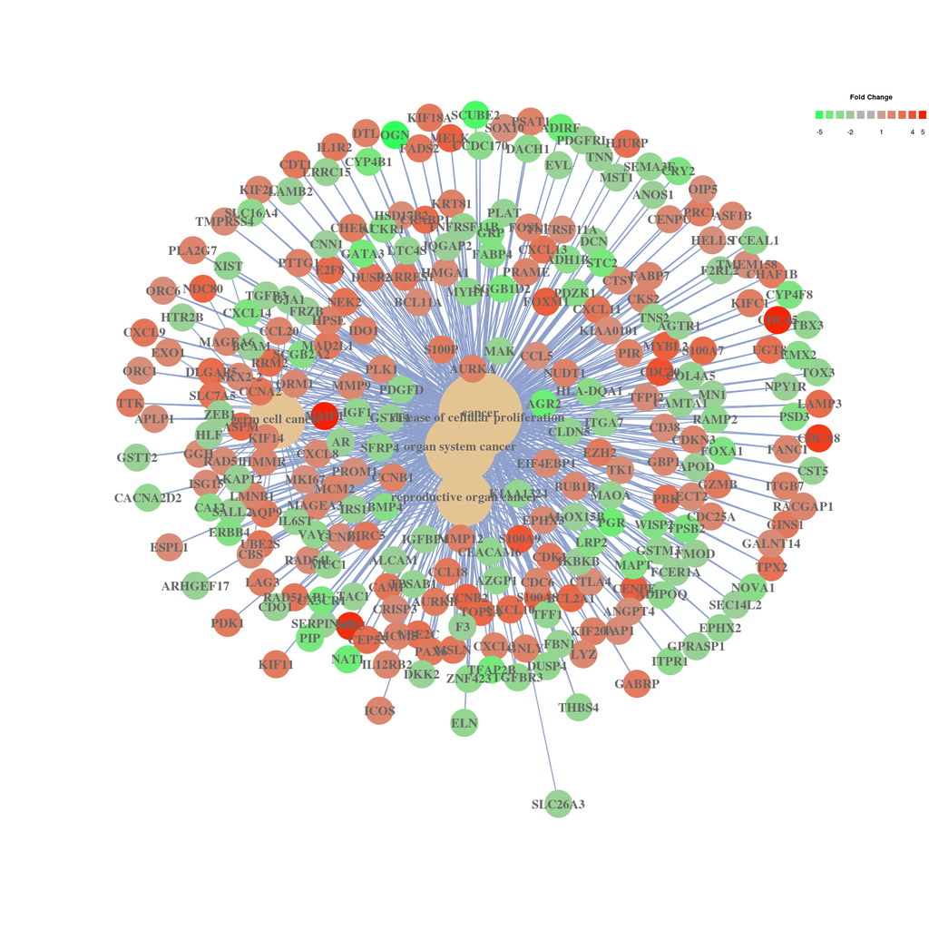

```r
cnetplot(x, categorySize="pvalue", foldChange=geneList)
```

## 6.4 Disease association comparison

We have developed an `R` package *[clusterProfiler](http://bioconductor.org/packages/release/bioc/html/clusterProfiler.html)*<sup>11</sup> for comparing biological themes among gene clusters. *[DOSE](http://bioconductor.org/packages/release/bioc/html/DOSE.html)* works fine with *[clusterProfiler](http://bioconductor.org/packages/release/bioc/html/clusterProfiler.html)* and can compare biological themes at disease perspective.

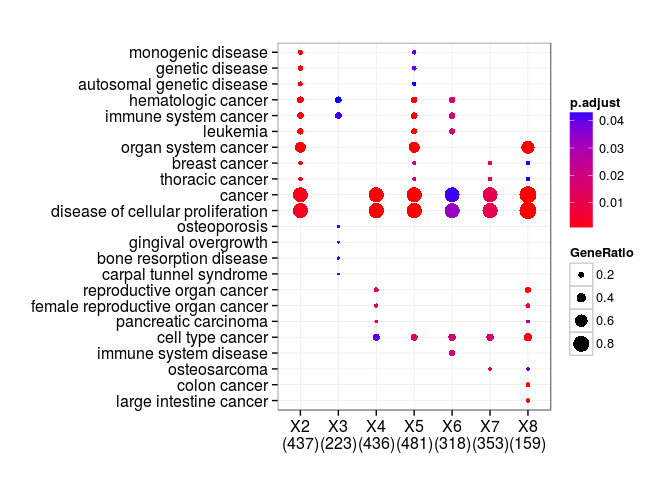

```r
require(clusterProfiler)
data(gcSample)
cdo <- compareCluster(gcSample, fun="enrichDO")
plot(cdo)
```

# 7 Disease analysis of NGS data

Disease analysis using NGS data (eg, RNA-Seq and ChIP-Seq) can be performed by linking coding and non-coding regions to coding genes via *[ChIPseeker](http://bioconductor.org/packages/release/bioc/html/ChIPseeker.html)* package, which can annotates genomic regions to their nearest genes, host genes, and flanking genes respectivly. In addtion, it provides a function, *seq2gene*, that simultaneously considering host genes, promoter region and flanking gene from intergenic region that may under control via cis-regulation. This function maps genomic regions to genes in a many-to-many manner and facilitate functional analysis. For more details, please refer to *[ChIPseeker](http://bioconductor.org/packages/release/bioc/html/ChIPseeker.html)*<sup>12</sup>.

# 8 Gene set enrichment analysis

## 8.1 GSEA algorithm

A common approach in analyzing gene expression profiles was identifying differential expressed genes that are deemed interesting. The enrichment analysis we demonstrated previous were based on these differential expressed genes. This approach will find genes where the difference is large, but it will not detect a situation where the difference is small, but evidenced in coordinated way in a set of related genes. Gene Set Enrichment Analysis (GSEA)<sup>13</sup> directly addresses this limitation. All genes can be used in GSEA; GSEA aggregates the per gene statistics across genes within a gene set, therefore making it possible to detect situations where all genes in a predefined set change in a small but coordinated way. Since it is likely that many relevant phenotypic differences are manifested by small but consistent changes in a set of genes.

Genes are ranked based on their phenotypes. Given a priori defined set of gens *S* (e.g., genes shareing the same *DO* category), the goal of GSEA is to determine whether the members of *S* are randomly distributed throughout the ranked gene list (*L*) or primarily found at the top or bottom.

There are three key elements of the GSEA method:

- Calculation of an Enrichment Score.
- The enrichment score (*ES*) represent the degree to which a set *S* is over-represented at the top or bottom of the ranked list *L*. The score is calculated by walking down the list *L*, increasing a running-sum statistic when we encounter a gene in *S* and decreasing when it is not. The magnitude of the increment depends on the gene statistics (e.g., correlation of the gene with phenotype). The *ES* is the maximum deviation from zero encountered in the random walk; it corresponds to a weighted Kolmogorov-Smirnov-like statistic<sup>13</sup>.
- Esimation of Significance Level of *ES*.
- The *p-value* of the is calculated using permutation test. Specifically, we permute the gene labels of the gene list *L* and recompute the *ES* of the gene set for the permutated data, which generate a null distribution for the *ES*. The *p-value* of the observed ES is then calculated relative to this null distribution.
- Adjustment for Multiple Hypothesis Testing.
- When the entire *DO* gene sets is evaluated, *[DOSE](http://bioconductor.org/packages/release/bioc/html/DOSE.html)* adjust the estimated significance level to account for multiple hypothesis testing and also *q-values* were calculated for FDR control.

## 8.2 gseAnalyzer fuction

In *[DOSE](http://bioconductor.org/packages/release/bioc/html/DOSE.html)*, we implemented GSEA algorithm proposed by Subramanian<sup>13</sup> in *gseAnalyzer* function.

In the following example, in order to speedup the compilation of this document, only gene sets with size above 120 were tested and only 100 permutations were performed.

```r
y <- gseAnalyzer(geneList,
                 setType       = "DO",
                 nPerm         = 100,
                 minGSSize     = 120,
                 pvalueCutoff  = 0.05,
                 pAdjustMethod = "BH",
                 verbose       = FALSE)
res <- summary(y)
head(res)
```

```
##                        ID                          Description setSize
## DOID:0050013 DOID:0050013      carbohydrate metabolism disease     619
## DOID:0050117 DOID:0050117          disease by infectious agent     851
## DOID:0050161 DOID:0050161      lower respiratory tract disease     455
## DOID:0050338 DOID:0050338 primary bacterial infectious disease     214
## DOID:0050615 DOID:0050615            respiratory system cancer     558
## DOID:0050686 DOID:0050686                  organ system cancer    2756
##              enrichmentScore     pvalue   p.adjust     qvalues
## DOID:0050013       0.2274608 0.00990099 0.01891796 0.005397156
## DOID:0050117       0.3112270 0.00990099 0.01891796 0.005397156
## DOID:0050161       0.3003701 0.00990099 0.01891796 0.005397156
## DOID:0050338       0.4569856 0.00990099 0.01891796 0.005397156
## DOID:0050615       0.3352210 0.00990099 0.01891796 0.005397156
## DOID:0050686       0.2507149 0.00990099 0.01891796 0.005397156
```

The *setType* should be one of “DO” or “DOLite and was required for *gseaAnalyzer* to prepare the corresponding gene sets. The *setType* can also be one of”GO" or “KEGG” if *[clusterProfiler](http://bioconductor.org/packages/release/bioc/html/clusterProfiler.html)* is loaded or “Reactome” if *[ReactomePA](http://bioconductor.org/packages/release/bioc/html/ReactomePA.html)* is loaded.

```r
topID <- res[1,1]
topID
```

```
## [1] "DOID:0050013"
```

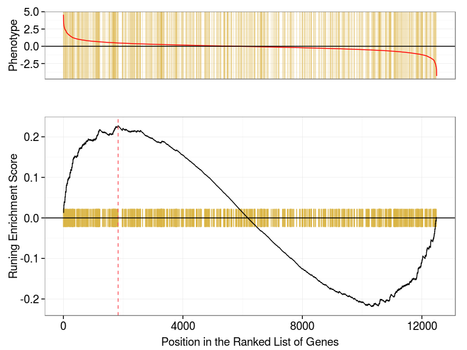

```r
plot(y, geneSetID = topID)
```

Parameter *geneSetID* can be numeric, the following command will generate the same figure as illustrated above.

```r
plot(y, geneSetID = 1)
```

# 9 enrichMap

Enrichment Map can be visualized by *enrichMap* function. It supports both enrichment result and GSEA result.

```r
enrichMap(x)
```

[figure not shown]